# Analisis De Tesis

## Solucion tecnologica

### Comunicación de servicios de la solución tecnológica

En esta sección explicamos la relación entre nuestros servicios de la arquitectura de nuestra propuesta de solución tecnológica.

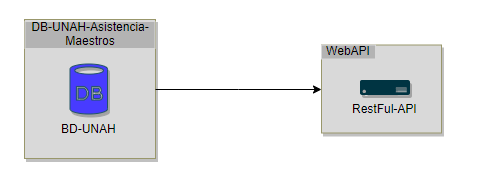

El objetivo que pretendemos alcanzar en la comunicación de estos 2 servicios como es el de base de datos UNAH y webAPI es consultar información específica del maestro como ser su asistencia con el objetivo global de presentarle posteriormente recomendaciones en base a información.

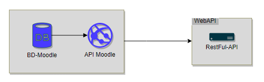

De igual forma para los servicios presentados como ser el de Moodle y nuestra WebAPI recordando que nuestra propuesta de solución tecnológica es Implementar el uso de LMS para aumentar el rendimiento del alumno y generar recomendaciones de mejores prácticas a los maestros el objetivo para estos dos componentes obtener información del LMS como ser control de seguimiento do los estudiantes además todos aquellos comentarios, observaciones de ellos mediante nuestro aplicativo para posteriormente toda esta data procesarla y generar las recomendaciones para el maestro.

[figure not shown]

El objetivo de relacionar estos tres servicios es que al haber consultado toda esa información pues someter esos datos mediante un proceso ETL para transformación de solo los datos que queremos para un posterior almacenamiento en una base de datos de tipo no relacional.

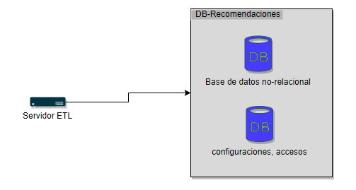

Como mencionamos una vez obtenidos los datos y procesados mediante ETL el objetivo es almacenarlos en una base de datos no relacional y el componente de base de datos relacional lo dejamos para controlar accesos y ciertas configuraciones de nuestra WebAPI y nuestra api de recomendaciones.

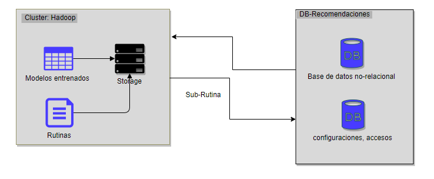

El objetivo de relación de estos servicios es que toda aquella información datos almacenarlos en un cluster de servidores con configuración Hadoop, además de eso pretendemos que nuestros servidores sean de tipo storage permitan almacenar y consultar una gran cantidad de datos y almacenar rutinas modelos entrenados que nos permitirá mediante minería de datos estudiantil y análisis predictivos generar las recomendaciones y consultarlas mediante las bases de datos de nuestros aplicativos.

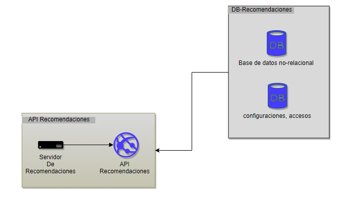

El objetivo de relación de estos servicios es que una vez ya tengamos generadas todas aquellas recomendaciones consultarlas mediante nuestro aplicativo de recomendaciones de mejores prácticas para ser presentados al usuario en este caso los maestros.

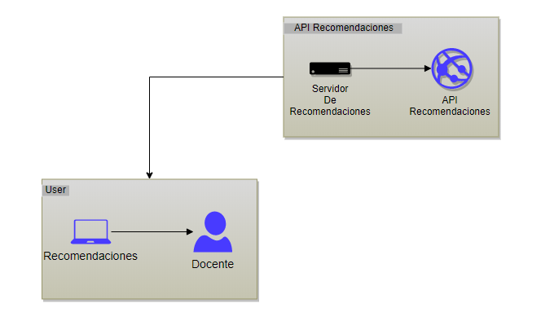

Por ultimo tenemos la relación entre estos servicios cuyo objetivo es que nuestro aplicativo le presente las recomendaciones de mejores prácticas al usuario maestro de cómo mejorar la dinámica de la clase que le sirva como un tipo de retroalimentación que le permitirá al docente como ejemplo cambiar la forma de como presentar mejor los contenidos sugerir nuevos o implementar prácticas que mejoren las condiciones de la clase para un mejor aprovechamiento del estudiante.

Por ultimo presentamos de forma completa la arquitectura de nuestra solución tecnológica.

### Arquitectura de solucion tecnologica

[figure not shown]